# NFL Injuries: Bayesian Inference

Brandon Owens

2024-04-10

## Background

With that being said, the NFL has instated over 50 rule changes to reduce player danger since 2002 alone.

## What Are We Looking At?

Have these significant rule changes that have caused controversy really impacted the athlete’s for the better? Many fans believe that the league is taking the fun out of the game by limiting the violent and aggressive nature of the sport. Thus, fan dichotomy has ensued surrounding the question of if these changes are really for the better?

Drawing on information from 2009-2013, we use this prior knowledge to inform three different distributions. * Beta Conjugate Model: To assess if the injury rate among players has declined over the last 10 seasons. * Dirichlet Conjugate Model: To assess the participation among age groups that comprise the NFL over the last 10 seasons. * Beta Conjuage Model: To assess the injury rate of players falling into a specific age rage amongst their peers in this age bin to gain insight on if age is a factor toward the injury rate.

Thus, we are interested in analyzing **if protocols set by the NFL to reduce player injury are successful or not over the last 10 years** and compare this question to other factors, like age.

### General Setup

#### Install Necessary Packages

```r
library(dplyr)
library(nflfastR)
library(LearnBayes)
library(extraDistr)
library(coda)
library(bayesrules)
library(ggridges)
```

```r
library(ggplot2)
library(tidyr)
library(lubridate)
library(BayesFactor)
library(cowplot)
```

#### Retrieve Players of Interest

```r
injury <- nflreadr::load_injuries(2009:2023)
injury <- injury[!duplicated(injury[c("full_name", "season")]),]

players <- nflreadr::load_rosters_weekly(2009:2023)
players <- players %>% filter(status %in% c("ACT", "RSN", "DEV", "PUP", "INA"))
players <- players[!duplicated(players[c("full_name", "season")]), ]
```

Here, we will be using [nflreadr](https://nflreadr.nflverse.com/), which is an absolutely phenominal package for NFL data. You can kind of data from the NFL-verse that you can think of using this package. Specifically, we are interested in two different areas:

- injuries
- players in the league

For this Bayesian Analysis, we are interested in gauging the percentage of players in the NFL that get injured year over year. We are only interested on whether or not a player gets hurt (not the amount of times they get hurt in a year) and whether or not they are actually a contributing member on a roster. Thus, players that are

- retired
- suspended
- on personal leave
- etc

are not included – as they have a much less likely chance of getting hurt if they aren’t actually playing.

## Part 1: Injury Rates in General

#### Form Dataframe with Desired Values

```r
player_counts <- numeric(length = 15)
injury_counts <- numeric(length = 15)

for (i in 1:15) {
  year <- 2008 + i

  player_counts[i] <- players %>% filter(season == year) %>% nrow()
  injury_counts[i] <- injury %>% filter(season == year, report_status %in% c("Out", "Doubtful", "Questionable")) %>% nrow()
}

dfall <- data.frame(
  year = c(2009:2023),
  number_of_players = player_counts,
  distinct_injuries = injury_counts,
  prob_inj = injury_counts/player_counts
)


df <- dfall %>% filter(year %in% (2014:2023))
```

Since the NFL-verse only has data from 2009-present for the weekly rosters and injury databases, we are only going to draw from 2009. For the sake of satisfaction, we are going to focus on Posterior distributions for only the last 10 years and use the prior information of anything after that as a basis for how injuries are designated. This is a nice place to start as clipping and unnecessary roughness penalties were expanded for blockers in the first year of our posterior (2014).

When it comes to what classifies as an injury, players on the depth chart that have maintained their roster spot that are listed as either:

- Out
- Doubtful
- Questionable are those that qualify.

Obviously many of these injuries will come from practice, where players are trying to be careful, but that is something we cannot account for. In other words, it is impossible to see if a player sustains an injury in practice or in the game unless every news source is tracked and maintained for player status. Thus, we assume that players sustaining injuries in practice is just a natural part of the game that will maintain some level of normal variation from season to season.

```r
df
```

```
##    year number_of_players distinct_injuries  prob_inj
## 1  2014              1736               596 0.3433180
## 2  2015              1730               624 0.3606936
## 3  2016              2714               782 0.2881356
## 4  2017              2401               714 0.2973761
## 5  2018              2430               613 0.2522634
## 6  2019              2440               661 0.2709016
## 7  2020              2716               719 0.2647275
## 8  2021              2677               682 0.2547628
## 9  2022              2631               734 0.2789814
## 10 2023              2645               735 0.2778828
```

### EDA:

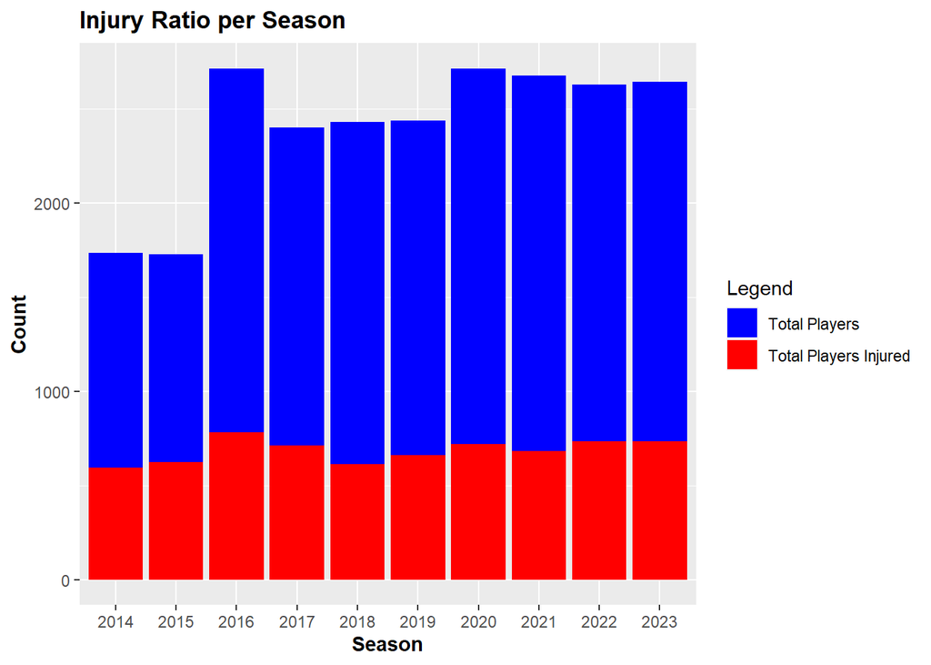

```r
p1 <- ggplot(data = df, aes(x = as.factor(year))) +
  geom_bar(aes(y = number_of_players, fill = "Total Players"), stat = "identity", position = "dodge") +
  geom_bar(aes(y = distinct_injuries, fill = "Total Players Injured"), stat = "identity", position = "dodge") +
  scale_fill_manual(values = c("Total Players" = "blue", "Total Players Injured" = "red"), name="Legend") +
  ggtitle("Injury Ratio per Season") +
  xlab("Season") + ylab("Count") +
  theme(
    plot.title = element_text(face="bold"),
    axis.title.x = element_text(face="bold"),
    axis.title.y = element_text(face="bold")
  )

print(p1)
```

I wanted to get a graphical representation of what the data looked like here. It seems that although the number of players being used in the league (blue) is increasing through the years (slightly, now), there seems to be more uniformity with the total players that were injured (red).

### Model Choice: Beta Conjugate

As mentioned in the background, we are opting for a binomial likelihood to approximate the number of players getting hurt out of the total number of players for the last ten seasons of the NFL. Utilizing a beta prior allows us the ease of manipulating a beta-conjugate posterior to obtain distributions of the percentage of all players that get hurt in the league for the last ten seasons.

#### Hyperparameter Choice

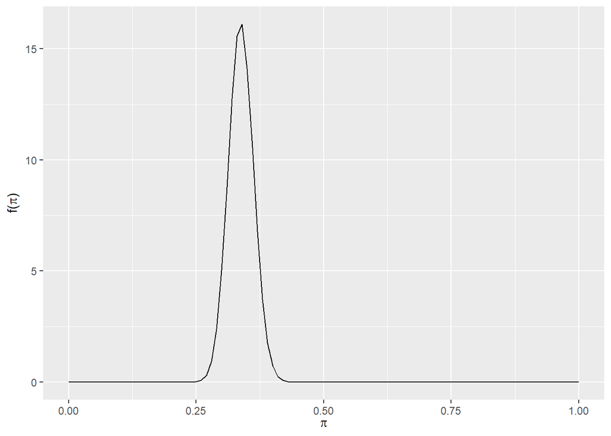

```r
plot_beta(125,245)
```

According to the [Bayes Rules!](https://www.bayesrulesbook.com/chapter-3) by Alicia Johnson, Mine Dogucu, and Miles Ott, the choice of hyperparameters for a beta prior should roughly model the mean and variance of our prior beliefs. Thus, we choose

- $alpha = 125$
- $beta = 245$

As our hyper parameters for our prior beta distribution.

#### Posterior: Beta-Conjugate

```r
iter <- 10000
n = df$number_of_players
x <- array(NA, c(iter, 10))
theta <- array(NA, c(iter, 10))

alpha <- 125
beta <-245

x[1, ]=df$distinct_injuries
theta[1, ]=df$prob_inj

for(i in 2:iter)
{
  x[i, ] <- rbinom(10, size = n, prob = theta[i - 1])
  theta[i, ] = rbeta(10, alpha+(x[i]), beta+n-(x[i]))
}
```

With a binomial likelihood and a beta prior, we find ourselves with a beta-conjugate posterior model.

Our model looks like this:

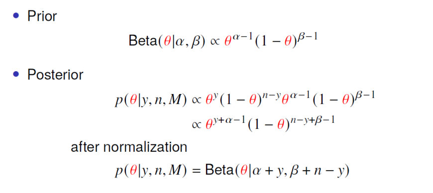

posterior

Where we could simply use an analytical format, but for added variance and attempting to learn more about simulation methods – we opt for Gibbs Sampling!

#### Convergence?

```r
Gibbs1=as.mcmc(theta[,1])
Gibbs2=as.mcmc(theta[,2])
Gibbs3=as.mcmc(theta[,3])
Gibbs4=as.mcmc(theta[,4])
Gibbs5=as.mcmc(theta[,5])
Gibbs6=as.mcmc(theta[,6])
Gibbs7=as.mcmc(theta[,7])
Gibbs8=as.mcmc(theta[,8])
Gibbs9=as.mcmc(theta[,9])
Gibbs10=as.mcmc(theta[,10])


Gibbs=mcmc.list(Gibbs1, Gibbs2, Gibbs3, Gibbs4, Gibbs5, Gibbs6, Gibbs7, Gibbs8, Gibbs9, Gibbs10)

raftery.diag(Gibbs)
```

```
## [[1]]
##
## Quantile (q) = 0.025
## Accuracy (r) = +/- 0.005
## Probability (s) = 0.95
##
##  Burn-in  Total Lower bound  Dependence
##  (M)      (N)   (Nmin)       factor (I)
##  14       16874 3746         4.5
##
##
## [[2]]
##
## Quantile (q) = 0.025
## Accuracy (r) = +/- 0.005
## Probability (s) = 0.95
##
##  Burn-in  Total Lower bound  Dependence
##  (M)      (N)   (Nmin)       factor (I)
##  10       11782 3746         3.15
##
##
## [[3]]
##
## Quantile (q) = 0.025
## Accuracy (r) = +/- 0.005
## Probability (s) = 0.95
##
##  Burn-in  Total Lower bound  Dependence
##  (M)      (N)   (Nmin)       factor (I)
##  10       11184 3746         2.99
##
##
## [[4]]
##
## Quantile (q) = 0.025
## Accuracy (r) = +/- 0.005
## Probability (s) = 0.95
##
##  Burn-in  Total Lower bound  Dependence
```

[output cut: 53 more lines]

```
##
##  Burn-in  Total Lower bound  Dependence
##  (M)      (N)   (Nmin)       factor (I)
##  10       12660 3746         3.38
##
##
## [[10]]
##
## Quantile (q) = 0.025
## Accuracy (r) = +/- 0.005
## Probability (s) = 0.95
##
##  Burn-in  Total Lower bound  Dependence
##  (M)      (N)   (Nmin)       factor (I)
##  8        10998 3746         2.94
```

We choose to run the Raftery-Lewis diagnostic, which gives us a good sense of how to make our MCMC draws converge. From here, it is apparent that using the same Gibbs sampling method… we should implement

- ~20,000 iterations
- ~20 sample burn-in
- 10 sample thinning

### Sampling

```r
iter <- 20000
n = df$number_of_players
x <- array(NA, c(iter, 10))
theta <- array(NA, c(iter, 10))

alpha <- 125
beta <- 245

x[1, ]=df$distinct_injuries
theta[1, ]=df$prob_inj

for(i in 2:iter)
{
  x[i, ] <- rbinom(10, size = n, prob = theta[i - 1])
  theta[i, ] = rbeta(10, alpha+(x[i]), beta+n-(x[i]))
}

x <- as.data.frame(x)
theta <- as.data.frame(theta)

binded <- cbind(x, theta)

burn <- 20
b <- burn + 1
k=10
N = round((iter-b)/k)

burned_df <- binded[b:iter, ]
final <- burned_df[k*(1:N), ]
```

#### Convergence Plots

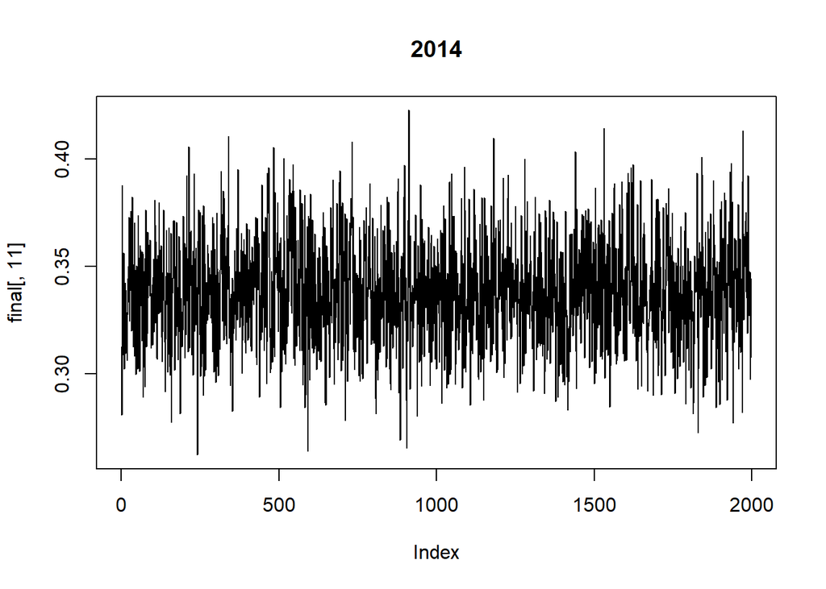

```r
plot(final[,11], type="l", main="2014")
```

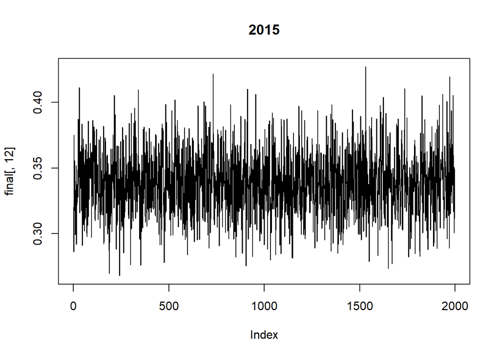

```r
plot(final[,12], type="l", main="2015")
```

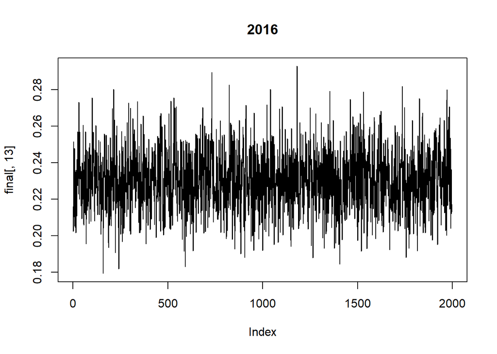

```r
plot(final[,13], type="l", main="2016")
```

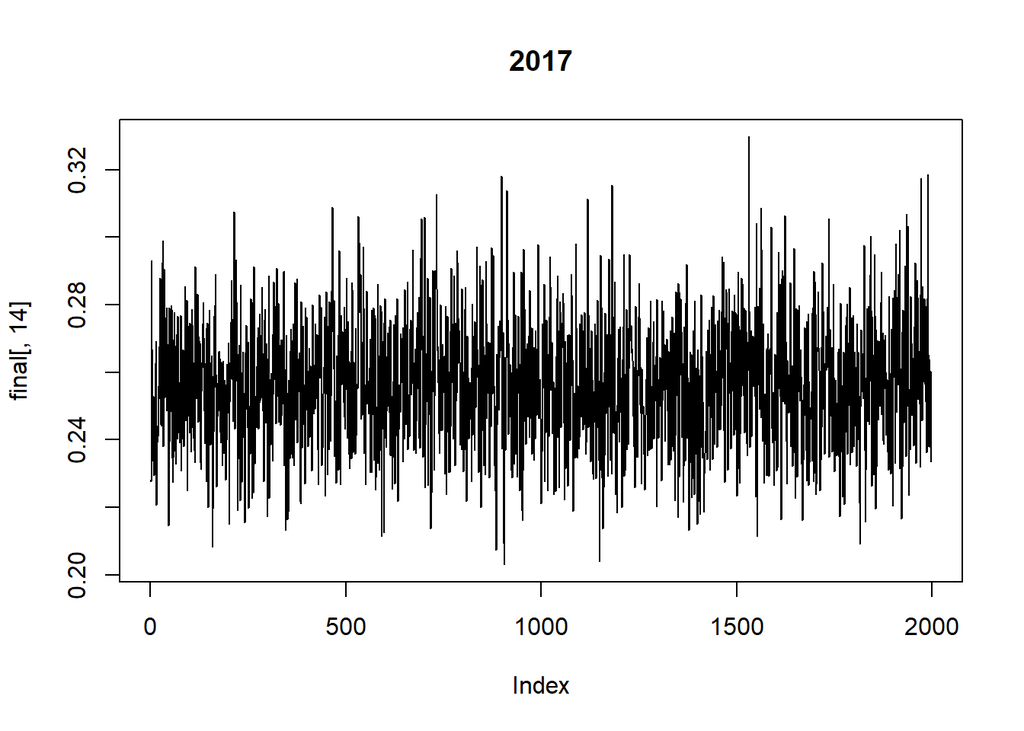

```r
plot(final[,14], type="l", main="2017")
```

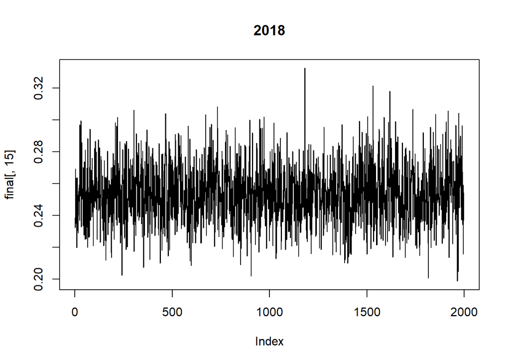

```r
plot(final[,15], type="l", main="2018")
```

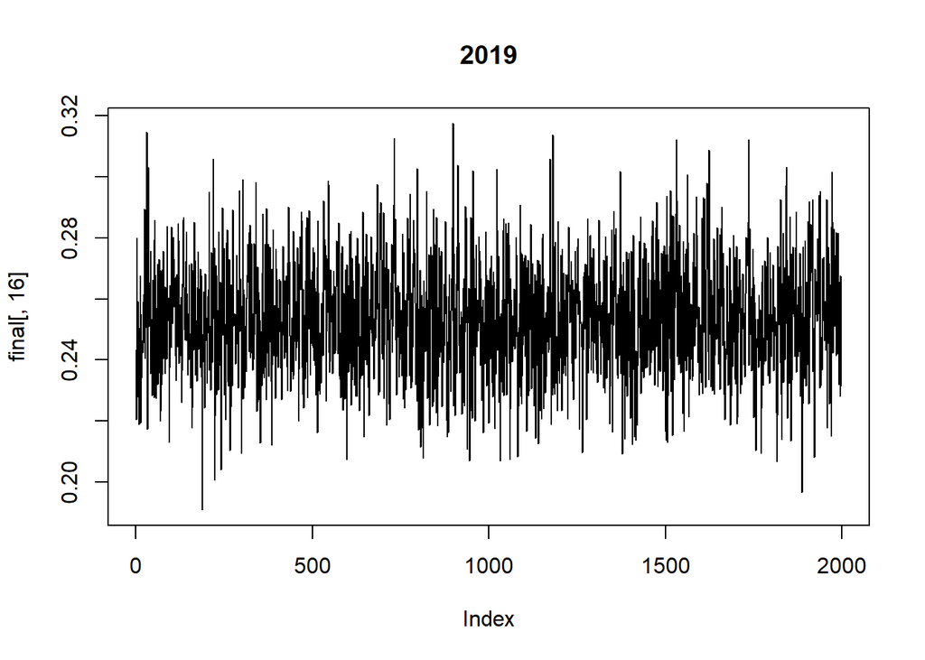

```r
plot(final[,16], type="l", main="2019")
```

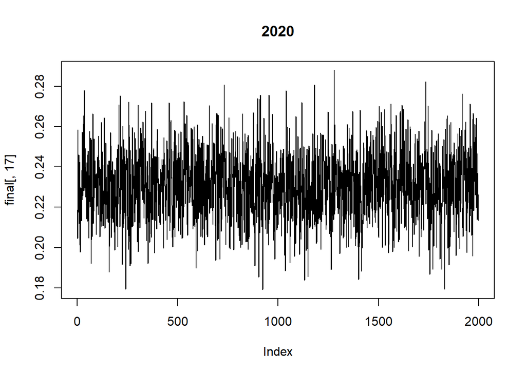

```r
plot(final[,17], type="l", main="2020")
```

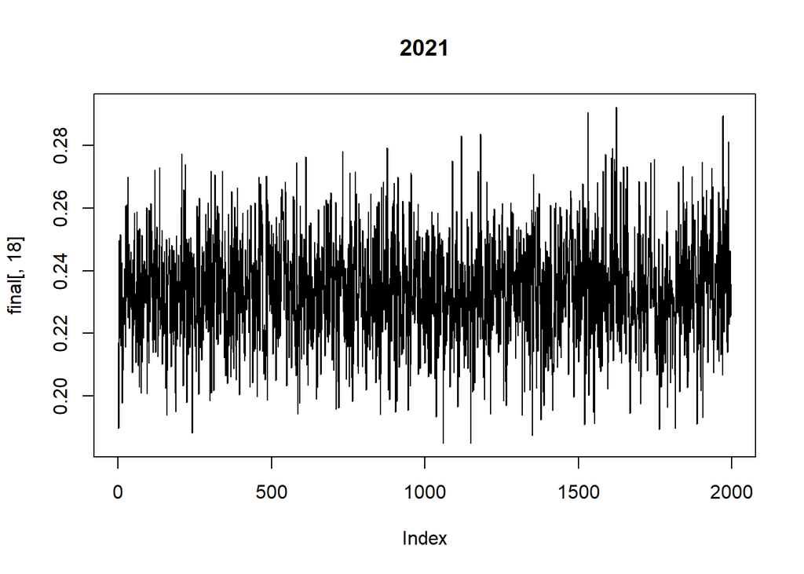

```r
plot(final[,18], type="l", main="2021")
```

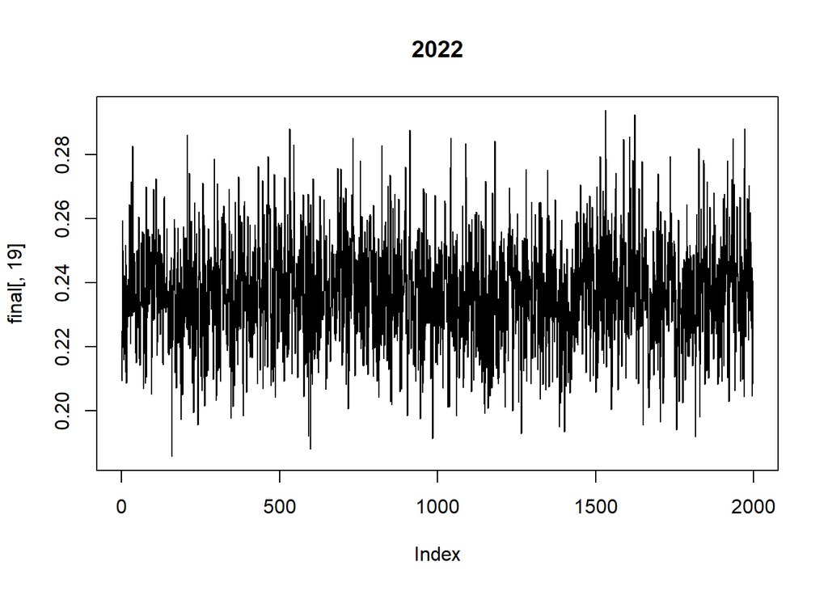

```r
plot(final[,19], type="l", main="2022")
```

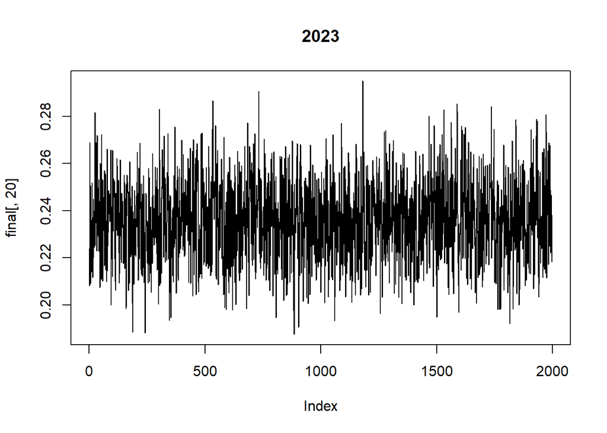

```r
plot(final[,20], type="l", main="2023")
```

From these plots of the theta draws from 2014-2023, we can see that our model appears to have converged well!

Now, it would be beneficial to reshape our dataframe of draws so that I can compare the posteriors in ggplot:

```r
final <- select(final, c(11:20))
colnames(final) <- c(2014:2023)

beta_sims <- rbeta(1998, 125, 245)
lower_ci <- quantile(beta_sims, 0.025)
higher_ci <- quantile(beta_sims, 0.975)
middle_ci <- mean(beta_sims)

final$Index <-seq_len(nrow(final))
melted_df <- pivot_longer(final, cols = -Index, names_to = "year", values_to = "value")
melted_df <- subset(melted_df, select = -Index)

melted_df$year <- as.factor(melted_df$year)
melted_df$value <- as.numeric(melted_df$value)
```

### Plots and Discussion

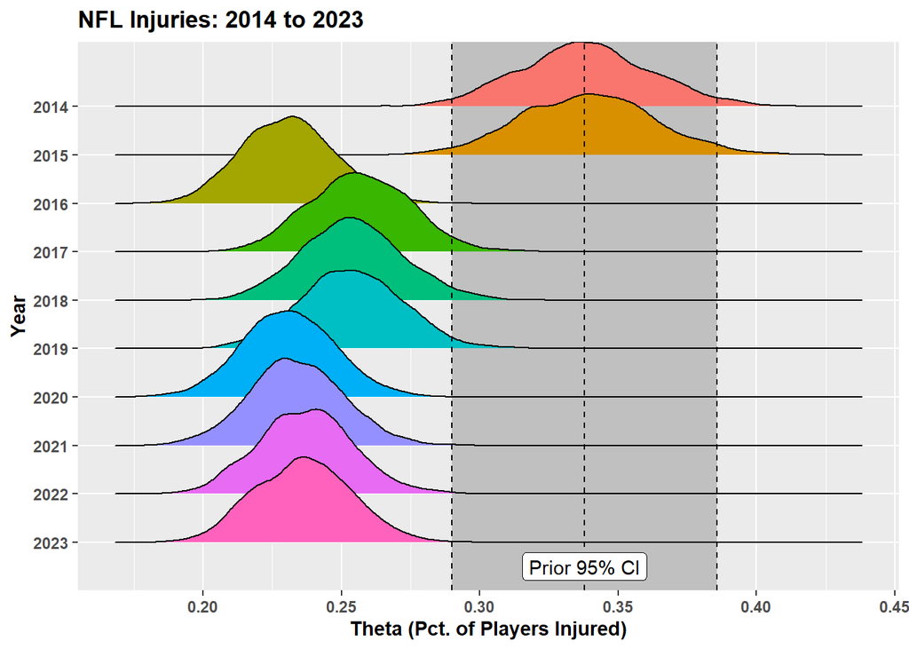

```r
p2 <- ggplot(melted_df, aes(x = value, y = year, group=year, fill=year)) +
  geom_rect(aes(xmin=lower_ci,xmax=higher_ci,ymin=0,ymax=Inf),fill="grey",alpha=.2) +
    geom_density_ridges() +
  geom_vline(xintercept=c(lower_ci, middle_ci, higher_ci),
           linetype="dashed", color = "black") +
    theme(
    axis.title = element_text(face = "bold"),
    axis.text = element_text(face = "bold"),
    plot.title = element_text(face = "bold"),
    legend.position = "none"
  ) +
  ggtitle("NFL Injuries: 2014 to 2023") +
  xlab("Theta (Pct. of Players Injured)") +
  ylab("Year") +
  scale_y_discrete(limits=rev) +
  annotate(
    geom = "label", x = middle_ci, y = 0.5,
    label = "Prior 95% CI", angle=90
  )

print(p2)
```

### Discussion Part 1

Some of the major rule changes that may explain the posteriors are as follows (from [NFL.com](https://www.nfl.com/playerhealthandsafety/equipment-and-innovation/rules-changes/nfl-health-and-safety-related-rules-changes-since-2002)):

- **2014:**
  - Clipping and unnecessary roughness penalties expanded to prohibit blockers from rolling up the side of a defender’s leg.
- **2015:**
  - “Peel back” blocks extended to offensive players.
  - Backs prohibited from chopping defensive players outside of tackle box.
  - No pushing teammates during kicking attempts.
  - Defenseless player protection expanded to receiver of a pass.
- **2016:**
  - Chop blocks prohibited.
  - Horse collar rule expanded.
  - Move touchback reception to 25 yard line.
- **2017:**
  - Prohibits “leaper” blocks on kicks.
  - Receivers running routes get defenseless player protections.
  - Prohibits crack-back blocks for players in motion.
- **2018:** *Lowering the head is officially a penalty to make a tackle.
- **2019:**
  - Expanded protection to defenseless players when initiating a block.
- **2020:**
  - Defenseless player protection expanded to returners.
  - Initial line blocking with the helmet removed.
- **2023:**
  - Fair catch goes to team’s 25 yard line hoping for more instances of fair catches.
  - Expands Impermissible Use of the helmet calls.

The most massive of the posterior distribution shifts comes in 2016, where previously the distributions greatly reflected the prior. With this large shift, it is hard to tell if one rule specifically caused the change, both rules together did, or with the new rules, there was a crackdown on officiating. Regardless, the previous four seasons have completely remained outside of our Prior distributions 95% confidence interval, signifying changes for the better when it comes to new rules and officiating! Perhaps this isn’t crystal clear, but I believe that as long as some sort of change is occurring to prove injury rates are declining YoY, then it doesn’t matter if it is the specific rule change or a change of referee rigidity. Next season will see updates to the entire format of the kickoff play and the swivel hip-drop tackle – two instances of the game being highly scrutinized for being dangerous… but also causing controversy with how difficult it will now be to tackle quarterbacks and larger players from behind.

### Conclusion Part 1

While there is evidence to demonstrate that the injury rate in the NFL has improved in the last ten years (especially compared to early years) it is unclear if the rule changes are *fully* responsible for the decrease in injury rate. Tightening of officiating is thought to be another major cause although this type of metric is much more difficult to express. This should be explored further.

Additionally, while cleaning the data, I opted to use a binomial model due to ease. The problem with this method lies in one distinct area: * Players are only classified as `injured_during_season` or `not_injured_during_season`. * If a player sustains more than one injury it is not shown. * Severity of injury is not distinguished. * Players can become injured at any time: even at practices our outside incidences. Thus I didn’t account for when and where the players developed their injuries. Therefore, it’s assumed that the rule changes help deload stress to players outside of game instances.

## Intermission

While analyzing the results from Part 1: Injury Analysis, my professor made some feedback on my project proposal. He mentioned that I could also analyze player durability through age bins within the data. I thought this was a fantastic idea and could possibly provide some insight to my part 1 analysis!

More specifically, what if there’s a chance that the new acquisition of skill in the NFL isn’t as good as it once was? This could potentially cause the league to have to hold onto older players…

Older players theoretically should elicit higher injury rates, as it is commonly studied that older athletes struggle to maintain power, speed, and muscle mass as they age. So as a way to test this theory or the composition of ages in the NFL and see if there’s any connection, we dive into some player background data…

## Part 2: Age Analysis

#### Age Data Cleaning

```r
players$age = ifelse(!is.na(players$birth_date), as.numeric(players$season) - as.numeric(format(as.Date(players$birth_date), "%Y")), players$years_exp + 22)

injury$age <- NA


for (i in seq_len(nrow(injury))) {
  matching_row <- which(players$full_name == injury$full_name[i])

  if (length(matching_row) > 0) {
    injury$age[i] <- players$age[matching_row]
  }
}
```

Here we had to make some assumptions to avoid major data loss. If `NFLreadR` didn’t include player age from the subset of players we were looking into earlier, I assumed to the player’s years of experience in the league + 22 (the average age when an NFL player graduates college to join the league) would suffice as a solid age metric.

```r
injury[is.na(injury$age),]
```

```
## ── nflverse injury & practice reports ──────────────────────────────────────────
```

```
## ℹ Data updated: 2024-03-15 03:13:49 EDT
```

```
## # A tibble: 186 × 17
##    season game_type team   week gsis_id  position full_name first_name last_name
##     <dbl> <chr>     <chr> <dbl> <chr>    <chr>    <chr>     <chr>      <chr>
##  1   2009 REG       ATL       1 00-0021… LB       Tony Gil… Tony       Gilbert
##  2   2009 REG       ATL       1 00-0018… LS       Mike Sch… Mike       Schneck
##  3   2009 REG       BUF       1 00-0026… TE       Derek Fi… Derek      Fine
##  4   2009 REG       CIN       1 00-0021… G        Scott Ko… Scott      Kooistra
##  5   2009 REG       CLE       1 00-0007… TE       Steve He… Steve      Heiden
##  6   2009 REG       DET       1 00-0021… TE       Casey Fi… Casey      Fitzsimm…
##  7   2009 REG       DET       1 00-0025… WR       Yamon Fi… Yamon      Figurs
##  8   2009 REG       IND       1 00-0023… CB       Marlin J… Marlin     Jackson
##  9   2009 REG       IND       1 00-0022… S        Bob Sand… Bob        Sanders
## 10   2009 REG       IND       1 00-0026… TE       Tom Santi Tom        Santi
## # ℹ 176 more rows
## # ℹ 8 more variables: report_primary_injury <chr>,
## #   report_secondary_injury <chr>, report_status <chr>,
## #   practice_primary_injury <chr>, practice_secondary_injury <chr>,
## #   practice_status <chr>, date_modified <dttm>, age <dbl>
```

```r
players[is.na(players$age),]
```

```
## ── nflverse weekly roster data ─────────────────────────────────────────────────
```

```
## ℹ Data updated: 2024-03-14 03:17:30 EDT
```

```
## # A tibble: 170 × 37
##    season team  position depth_chart_position jersey_number status full_name
##     <int> <chr> <chr>    <chr>                <chr>         <chr>  <chr>
##  1   2016 TEN   LB       LB                   59            ACT    Tim Shaw
##  2   2016 NO    DL       DE                   91            ACT    Matt Shaughn…
##  3   2016 NE    LB       LB                   52            PUP    Dane Fletcher
##  4   2016 KC    WR       WR                   15            ACT    Mike Williams
##  5   2016 BUF   DL       DE                   98            ACT    Brandon Dead…
##  6   2016 CAR   DB       DB                   36            DEV    Ras-I Dowling
##  7   2016 MIA   DB       DB                   29            ACT    Brandon Harr…
##  8   2016 MIA   RB       RB                   30            ACT    Daniel Thomas
##  9   2016 PHI   QB       QB                   4             ACT    McLeod Bethe…
## 10   2016 DAL   OL       OT                   64            ACT    Cameron Brad…
## # ℹ 160 more rows
## # ℹ 30 more variables: first_name <chr>, last_name <chr>, birth_date <date>,
## #   height <dbl>, weight <int>, college <chr>, gsis_id <chr>, espn_id <chr>,
## #   sportradar_id <chr>, yahoo_id <chr>, rotowire_id <chr>, pff_id <chr>,
## #   pfr_id <chr>, fantasy_data_id <chr>, sleeper_id <chr>, years_exp <int>,
## #   headshot_url <chr>, ngs_position <chr>, week <int>, game_type <chr>,
## #   status_description_abbr <chr>, football_name <chr>, esb_id <chr>, …
```

```r
injury[is.na(injury$gsis_id),]
```

```
## ── nflverse injury & practice reports ──────────────────────────────────────────
```

```
## ℹ Data updated: 2024-03-15 03:13:49 EDT
```

```
## # A tibble: 0 × 17
## # ℹ 17 variables: season <dbl>, game_type <chr>, team <chr>, week <dbl>,
## #   gsis_id <chr>, position <chr>, full_name <chr>, first_name <chr>,
## #   last_name <chr>, report_primary_injury <chr>,
## #   report_secondary_injury <chr>, report_status <chr>,
## #   practice_primary_injury <chr>, practice_secondary_injury <chr>,
## #   practice_status <chr>, date_modified <dttm>, age <dbl>
```

```r
players[is.na(players$gsis_id),]
```

```
## ── nflverse weekly roster data ─────────────────────────────────────────────────
```

```
## ℹ Data updated: 2024-03-14 03:17:30 EDT
```

```
## # A tibble: 15 × 37
##    season team  position depth_chart_position jersey_number status full_name
##     <int> <chr> <chr>    <chr>                <chr>         <chr>  <chr>
##  1   2018 NE    WR       WR                   <NA>          RSN    Darren Andre…
##  2   2018 SF    WR       WR                   <NA>          DEV    Frank Stephe…
##  3   2018 NYG   P        P                    <NA>          DEV    Brock Miller
##  4   2019 NE    K        K                    <NA>          DEV    Josh Gable
##  5   2019 ATL   WR       WR                   <NA>          DEV    Tavonn Salter
##  6   2020 HOU   DB       DB                   27            DEV    Manny Patter…
##  7   2020 GB    K        K                    0             DEV    J.J. Molson
##  8   2021 KC    TE       TE                   <NA>          DEV    Mark Vital
##  9   2021 BAL   LB       ILB                  48            DEV    Blake Gallag…
## 10   2021 SEA   TE       TE                   <NA>          DEV    DeShon Willi…
## 11   2021 HOU   OL       G                    <NA>          DEV    Sam Cooper
## 12   2022 ATL   RB       FB                   <NA>          DEV    Clint Ratkov…
## 13   2022 ATL   WR       WR                   <NA>          DEV    Emeka Emezie
## 14   2022 IND   K        K                    3             DEV    Lucas Havris…
## 15   2023 DEN   LB       LB                   <NA>          DEV    Durell Nchami
## # ℹ 30 more variables: first_name <chr>, last_name <chr>, birth_date <date>,
## #   height <dbl>, weight <int>, college <chr>, gsis_id <chr>, espn_id <chr>,
## #   sportradar_id <chr>, yahoo_id <chr>, rotowire_id <chr>, pff_id <chr>,
## #   pfr_id <chr>, fantasy_data_id <chr>, sleeper_id <chr>, years_exp <int>,
## #   headshot_url <chr>, ngs_position <chr>, week <int>, game_type <chr>,
## #   status_description_abbr <chr>, football_name <chr>, esb_id <chr>,
## #   gsis_it_id <chr>, smart_id <chr>, entry_year <int>, rookie_year <int>, …
```

There’s some obvious data loss, but not enough to really skew our thousands of rows of information. Because the age loss and id loss is so minimal, we will choose to ignore it.

```r
age_bin_20_24 <- numeric(length = 15)
age_bin_25_29 <- numeric(length = 15)
age_bin_30_34 <- numeric(length = 15)
age_bin_35_up <- numeric(length = 15)

age_bin_20_24_hurt <- numeric(length = 15)
age_bin_25_29_hurt <- numeric(length = 15)
age_bin_30_34_hurt <- numeric(length = 15)
age_bin_35_up_hurt <- numeric(length = 15)

for (i in 1:15) {
  year <- 2008 + i

  age_bin_20_24[i] <- players %>% filter(season == year, age >= 20, age < 25) %>% nrow()
  age_bin_25_29[i] <- players %>% filter(season == year, age >= 25, age < 30) %>% nrow()
  age_bin_30_34[i] <- players %>% filter(season == year, age >= 30, age < 35) %>% nrow()
  age_bin_35_up[i] <- players %>% filter(season == year, age >= 35) %>% nrow()

  age_bin_20_24_hurt[i] <- injury %>% filter(season == year, report_status %in% c("Out", "Doubtful", "Questionable"),  age >= 20, age < 25) %>% nrow()
  age_bin_25_29_hurt[i] <- injury %>% filter(season == year, report_status %in% c("Out", "Doubtful", "Questionable"), age >= 25, age < 30) %>% nrow()
  age_bin_30_34_hurt[i] <- injury %>% filter(season == year, report_status %in% c("Out", "Doubtful", "Questionable"),  age >= 30, age < 35) %>% nrow()
  age_bin_35_up_hurt[i] <- injury %>% filter(season == year, report_status %in% c("Out", "Doubtful", "Questionable"), age >= 35) %>% nrow()
}

dfallage <- data.frame(
  year = c(2009:2023),
  number_of_players = player_counts,
  number_of_players_age_listed = (age_bin_20_24 + age_bin_25_29 + age_bin_30_34 + age_bin_35_up),
  distinct_injuries = injury_counts,
  disting_injuries_age_listed = (age_bin_20_24_hurt + age_bin_25_29_hurt + age_bin_30_34_hurt + age_bin_35_up_hurt),
  prob_inj = injury_counts/player_counts,
  age_20_24 = age_bin_20_24,
  age_20_24_hurt = age_bin_20_24_hurt,
  age_25_29 = age_bin_25_29,
  age_25_29_hurt = age_bin_25_29_hurt,
  age_30_34 = age_bin_30_34,
  age_30_34_hurt = age_bin_30_34_hurt,
  age_35_up = age_bin_35_up,
  age_35_up_hurt = age_bin_35_up_hurt
)

dfage <- dfallage %>% filter(year %in% (2014:2023))
```

We needed to separate ages into different bins and the number of those players that were injured into their own columns so we could have a metric for each year.

```r
dfage
```

```
##    year number_of_players number_of_players_age_listed distinct_injuries
## 1  2014              1736                         1736               596
## 2  2015              1730                         1730               624
## 3  2016              2714                         2549               782
## 4  2017              2401                         2401               714
## 5  2018              2430                         2427               613
## 6  2019              2440                         2438               661
## 7  2020              2716                         2716               719
## 8  2021              2677                         2677               682
## 9  2022              2631                         2631               734
## 10 2023              2645                         2645               735
##    disting_injuries_age_listed  prob_inj age_20_24 age_20_24_hurt age_25_29
## 1                          592 0.3433180       614            453       848
## 2                          615 0.3606936       613            504       845
## 3                          781 0.2881356       974            680      1201
```

[output cut: 18 more lines]

As mentioned earlier, we have some definite data loss primarily in:

### EDA

```r
melted_df <- dfage %>%
  pivot_longer(cols = c(age_20_24, age_25_29, age_30_34, age_35_up)) %>%
  mutate(name = factor(name, levels = c("age_20_24", "age_25_29", "age_30_34", "age_35_up")))
```

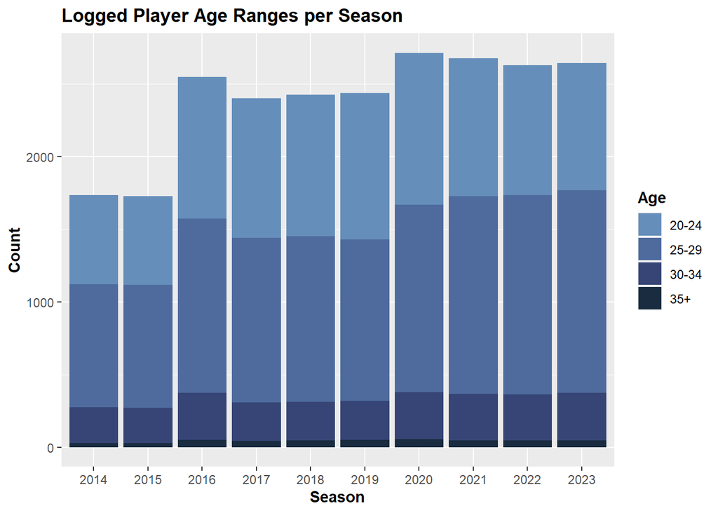

```r
p3 <- ggplot(data = melted_df, aes(x = as.factor(year), y = value, fill = name)) +
  geom_bar(stat = "identity", position = "stack") +
  ggtitle("Logged Player Age Ranges per Season") +
  xlab("Season") + ylab("Count") +
  scale_fill_manual(values = c("age_20_24" = "#658eba",
                                "age_25_29" = "#4f6b9e",
                                "age_30_34" = "#364575",
                                "age_35_up" = "#192c40"), name = "Age",
                    labels= c("20-24",
                              "25-29",
                              "30-34",
                              "35+")) +
  theme(
    plot.title = element_text(face = "bold"),
    axis.title.x = element_text(face = "bold"),
    axis.title.y = element_text(face = "bold"),
    legend.title = element_text(face = "bold")
  )

print(p3)
```

We comprise the makeup of players with actual logged ages for our years of interest in the league. It seems our original hypothesis may not be as strong as we initially hoped. In other words, we notice:

- The league size is growing.
- The number of older players is marginally growing.
- The most growth comes from players considered during their prime years: 25-29 years old. We will look further at this.

```r
melted_df <- dfage %>%
  pivot_longer(cols = c(number_of_players_age_listed, age_20_24_hurt, age_25_29_hurt, age_30_34_hurt, age_35_up_hurt)) %>%
  mutate(name = factor(name, levels = c("age_20_24_hurt", "age_25_29_hurt", "age_30_34_hurt", "age_35_up_hurt", "number_of_players_age_listed")))
```

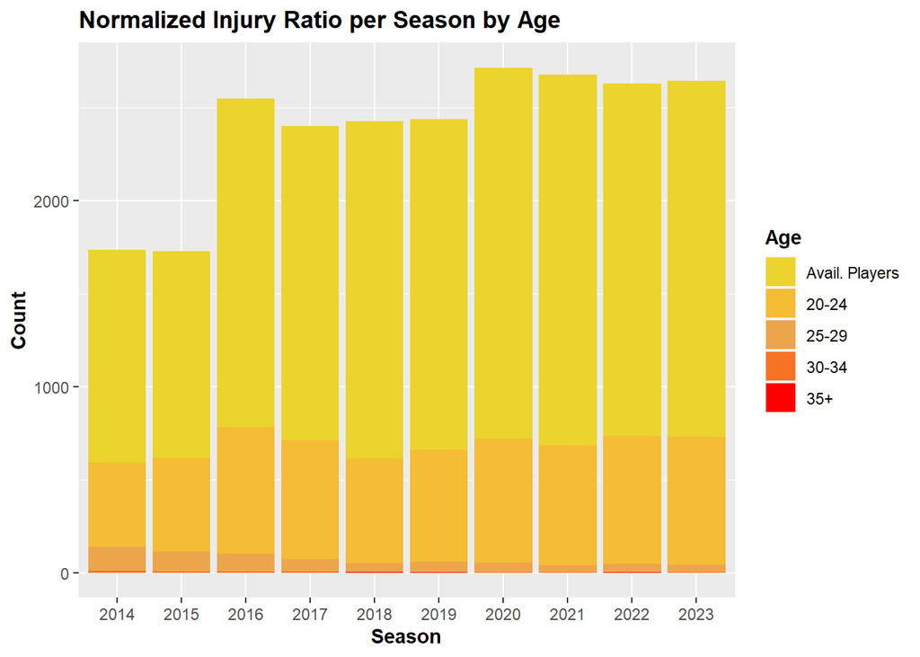

```r
p4 <- ggplot(data = melted_df, aes(x = as.factor(year), y = value, fill = name)) +
  geom_bar(data = filter(melted_df, name == "number_of_players_age_listed"),
           aes(x = as.factor(year), y = value, fill = name),
           stat = "identity", position = "dodge") +
  geom_bar(data = filter(melted_df, name != "number_of_players_age_listed"),
           aes(x = as.factor(year), y = value, fill = name),
           stat = "identity", position = "stack") +
  ggtitle("Normalized Injury Ratio per Season by Age") +
  xlab("Season") + ylab("Count") +
  scale_fill_manual(values = c("number_of_players_age_listed" = "#ebd42d",
                                "age_20_24_hurt" = "#f5bc36",
                                "age_25_29_hurt" = "#eda54c",
                                "age_30_34_hurt" = "#f77225",
                                "age_35_up_hurt" = "red"), name = "Age",
                    labels= c("Avail. Players",
                              "20-24",
                              "25-29",
                              "30-34",
                              "35+")) +
  theme(
    plot.title = element_text(face = "bold"),
    axis.title.x = element_text(face = "bold"),
    axis.title.y = element_text(face = "bold"),
    legend.title = element_text(face="bold")
  )

print(p4)
```

This plot pretty clearly demonstrates that older players actually aren’t the ones getting hurt! Who would have thought! Some possible reasons for this finding may be that: * There just aren’t a lot of older players in the league. * Older players may not receive the game frequency or practice volume that younger players receive. * A lot of the older players may have more durable position types that allow them to avoid contact situations, like punters, kickers, backup quarterbacks, etc.

So maybe age does play a difference, just not in the way that we thought.

```r
players <- players[!is.na(players$age),]

for (i in 1:15) {
  year <- 2008 + i
  player_counts[i] <- players %>% filter(season == year) %>% nrow()
  age_bin_20_24[i] <- players %>% filter(season == year, age >= 20, age < 25) %>% nrow()
  age_bin_25_29[i] <- players %>% filter(season == year, age >= 25, age < 30) %>% nrow()
  age_bin_30_34[i] <- players %>% filter(season == year, age >= 30, age < 35) %>% nrow()
  age_bin_35_up[i] <- players %>% filter(season == year, age >= 35) %>% nrow()
}

players_age <- players %>%
  summarize(
    total = player_counts,
    a20_24 = age_bin_20_24,
    a25_29 = age_bin_25_29,
    a30_34 = age_bin_30_34,
    a35_up = age_bin_35_up,
    pct20_24 = age_bin_20_24/player_counts,
    pct25_29 = age_bin_25_29/player_counts,
    pct30_34 = age_bin_30_34/player_counts,
    pct35_up = age_bin_35_up/player_counts,
  )
```

### Modelling: Dirichlet Conjugate

#### Which Age Bin Dominates the League? (Dirichlet Conjugate)

##### Prior and Hyperparameters

It seems logical to start with some modelling to see how the composition of ages in the league has changed over time. With this, a multinomial likelihood model (with Dirichlet conjugacy for ease) seems like the appropriate route to estimate the percent compositions of these different age bins.

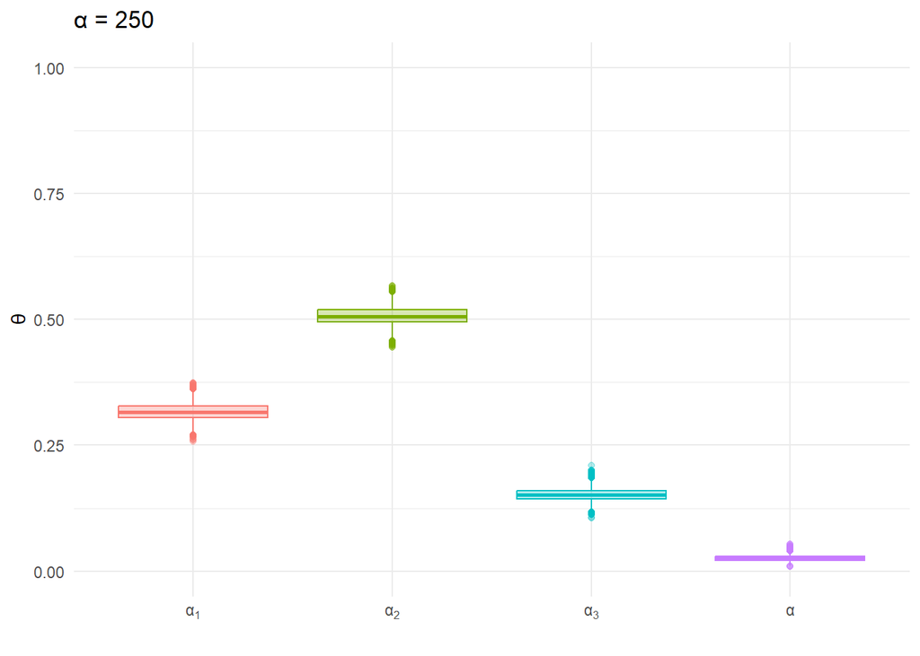

```r
alpha <- c(250,400,120,20)
trials <- 10000
x <- rdirichlet(trials, alpha)
colnames(x) <- c('theta_1', 'theta_2', 'theta_3', 'theta_4')
ds <- cbind(as_tibble(x), trial = 1:trials) %>%
  gather(theta, word, -trial)

ggplot(ds, aes(color = theta, fill = theta, x = theta, y = word)) + geom_boxplot(alpha = 0.3) +
  theme_minimal() +
  labs(y='\U03B8', x = '', title = paste0("\U03B1 = ",unique(alpha)) ) +
  scale_x_discrete(labels = c(expression("\U03B1"[1]),
                              expression("\U03B1"[2]),
                              expression("\U03B1"[3]),
                              expression("\U03B1"))) +
  scale_fill_discrete(guide = FALSE) +
  scale_color_discrete(guide = FALSE)+
  scale_y_continuous(limits = c(0,1))
```

With the thought in mind of initiating a multinomial likelihood distribution and a Dirichlet prior for a conjugate Dirichlet posterior, we need to determine our hyperparameters for the Dirichlet prior. Found from the [LDA Inference Book](https://miningthedetails.com/LDA_Inference_Book/multinomial-distribution.html), we once again go back to our prior information of 2009-2013. The age composition of the league seems to have the following variation and means for the four age groups as seen as above.

Thus, we choose our alpha parameter to be a vector of: $alpha = (250, 400, 120, 20)$

##### Analytical Simulation of Posterior: Dirichlet

```r
iter <- 10000

alpha <- c(250,400,120,20)
n_matrix <- subset(players_age[6:15, 2:5])
sims <- array(NA, c(iter, length(alpha), nrow(n_matrix)))

for (i in 1:10){
  sims[, ,i] = rdirichlet(iter, (alpha + n_matrix[i,]))
}
```

We draw 10,000 draws for our 4 bins for our 10 seasons.

```r
years <- rep(2014:2023, each=40000)
categories <- rep(1:4, each=10000, times=10)
simulations <- c(sims)

ages_sims_df <- data.frame(
  years = years,
  age_bins = categories,
  sims = simulations
)
```

#### Plotting

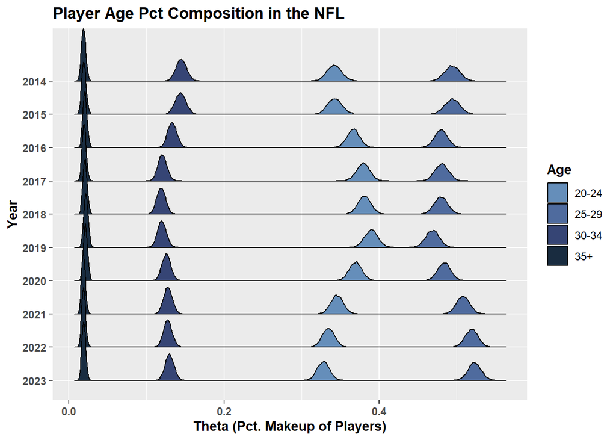

```r
ages_sims_df$age_bins <- as.factor(ages_sims_df$age_bins)

age_bin_colors <- c("1" = "#658eba",
                   "2" = "#4f6b9e",
                   "3" = "#364575",
                   "4" = "#192c40")

age_bin_labels <- c("1" = "20-24",
                   "2" = "25-29",
                   "3" = "30-34",
                   "4" = "35+")

p5 <- ggplot(ages_sims_df, aes(x = sims, y = factor(years), fill = age_bins)) +
  geom_density_ridges() +
  scale_fill_manual(values = age_bin_colors, labels = age_bin_labels) +
  guides(fill = guide_legend(title = "Age")) +
  theme(
    axis.title = element_text(face = "bold"),
    axis.text = element_text(face = "bold"),
    plot.title = element_text(face = "bold"),
    legend.title = element_text(face = "bold")
  ) +
  ggtitle("Player Age Pct Composition in the NFL") +
  xlab("Theta (Pct. Makeup of Players)") +
  ylab("Year") +
  scale_y_discrete(limits=rev)

print(p5)
```

From our ridge posterior graph, we can see that the ages of older players actually remain relatively the same throughout the last 10 seasons of the NFL. Meanwhile, the shift occurs from players in their 20’s. In the mid 2010s there was a change where there was a noticeable chunk of new talent acquisition into the league, but over the last few years of the 2020s, these players have gotten older and moved into the 25-29 year old range.

##### Discussion Part 2

Witnessing the slight variation of newer players into the league around the 2017-2020 time period, it draws and interesting comparison to our previous posterior plot…

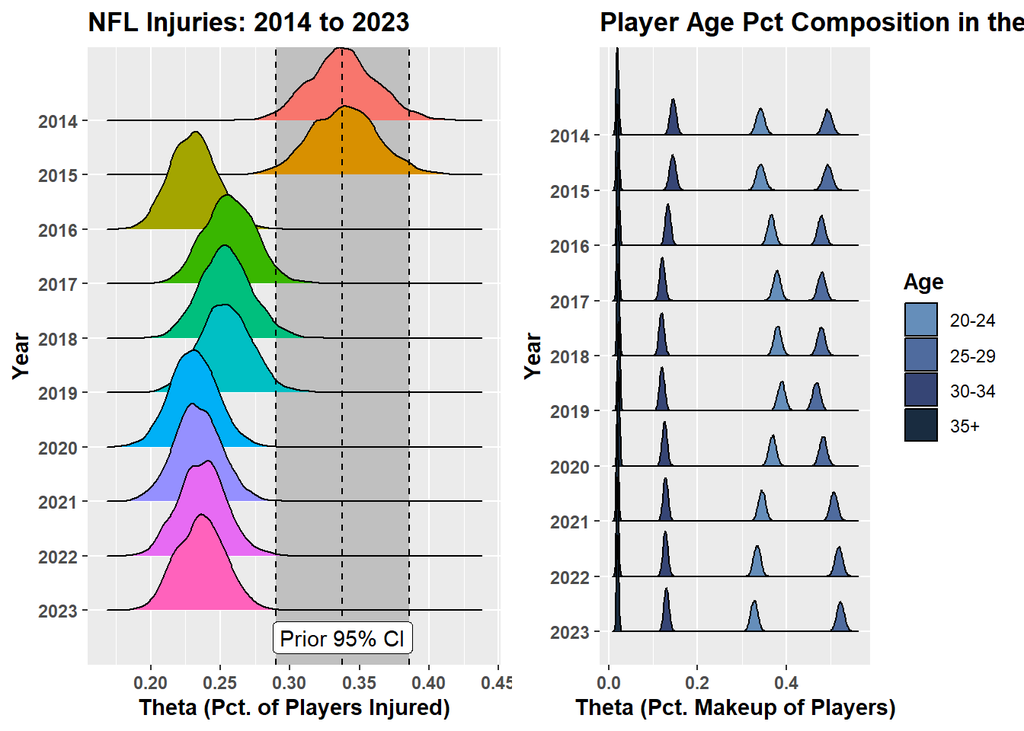

```r
plot_grid(p2, p5)
```

These plots share an interesting trend: from 2017 to 2019, there appears to be a slight shift towards younger athlete’s entering the league. After the major shift from 2016 in injury rate, posteriors begin to regress back toward the prior slightly, before moving away again in 2020, around the time those one newer players have entered a new age bracket and there’s a greater proportion of 25-29 year-olds in the league.

This could signify that new players in the NFL struggle with the physicality of the game and were responsible for some deviation of the league injury rate. Another theory could be that athletes are just becoming too explosive for their own good at too young of an age. Next, I would like to dive into the percentage of different age groups that have gotten hurt out of the available players in those groups each year.

#### Which Age Bin is Most Likely to be Injured?

With that comparison of our two posteriors, let’s try to model something new. We are now interested in which types of players are getting hurt the most relative to the other players that are their age?

#### Which Ages Are Getting Hurt the Most?

##### Some More Data Cleaning

```r
players_age2 <- data.frame(
  year = c(2009:2023),
  t2024 = age_bin_20_24,
  t2529 = age_bin_25_29,
  t3034 = age_bin_30_34,
  t35p = age_bin_35_up,
  th2024 = age_bin_20_24_hurt,
  th2529 = age_bin_25_29_hurt,
  th3034 = age_bin_30_34_hurt,
  th35p = age_bin_35_up_hurt,
  tp2024 = age_bin_20_24_hurt / age_bin_20_24,
  tp2529 = age_bin_25_29_hurt / age_bin_25_29,
  tp3034 = age_bin_30_34_hurt / age_bin_30_34,
  tp35p = age_bin_35_up_hurt / age_bin_35_up
)
```

```r
players_age2
```

```
##    year t2024 t2529 t3034 t35p th2024 th2529 th3034 th35p    tp2024     tp2529
## 1  2009   563   810   291   51    159    280     94    10 0.2824156 0.34567901
## 2  2010   565   829   279   43    247    254     73     8 0.4371681 0.30639324
## 3  2011   580   815   270   50    328    218     58     3 0.5655172 0.26748466
## 4  2012   594   829   246   46    351    174     28     1 0.5909091 0.20989144
## 5  2013   617   836   246   35    381    157     11     0 0.6175041 0.18779904
## 6  2014   614   848   246   28    453    131      8     0 0.7377850 0.15448113
## 7  2015   613   845   243   29    504    105      6     0 0.8221860 0.12426036
## 8  2016   974  1201   325   49    680     97      4     0 0.6981520 0.08076603
## 9  2017   960  1133   265   43    642     66      5     0 0.6687500 0.05825243
## 10 2018   975  1142   263   47    565     43      4     1 0.5794872 0.03765324
## 11 2019  1008  1112   267   51    605     53      2     1 0.6001984 0.04766187
## 12 2020  1045  1295   321   55    666     50      3     0 0.6373206 0.03861004
## 13 2021   948  1361   323   45    644     37      1     0 0.6793249 0.02718589
## 14 2022   894  1376   316   45    689     42      2     1 0.7706935 0.03052326
```

[output cut: 17 more lines]

##### Prior and Hyperparameters

Similarly to our first bayesian model that looked to create distributions to model the percentage of players getting hurt out of all players available, it seems logical to use the same framework of a model for each individual age bin. This answers the question: what percentage of athletes get hurt compared to their respective age.

We will use a beta conjugate model once again with a binomial likelihood – this time analytically.

Similar to our methodology for determining hyperparameters $alpha$ and $beta$ earlier, we used the same empirical technique.

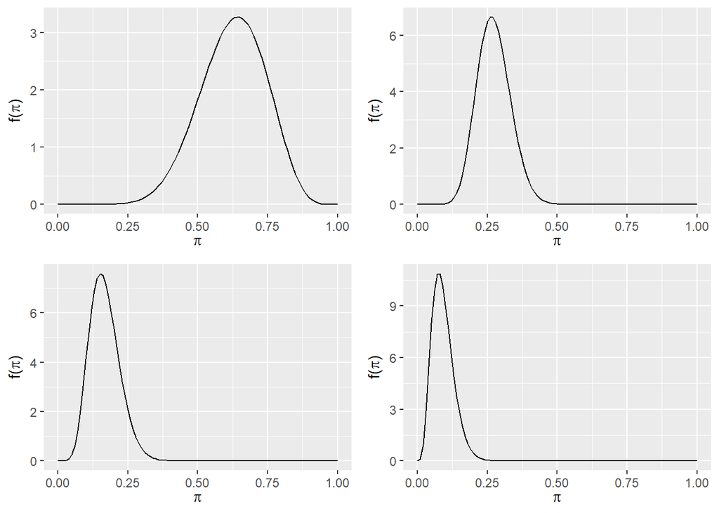

```r
plot_grid(plot_beta(10, 6), plot_beta(15, 40), plot_beta(8, 40), plot_beta(5,50))
```

These beta distributions model the prior known information of percent likelihood for a player to be injured amongst their age peers.

##### Analytical Posterior

```r
alpha = c(10, 15, 8, 5)
beta = c(6, 40, 40, 50)

for (i in 1:10){
  for (j in 1:iter){
    sims[j, ,i] <- rbeta(4, alpha + (as.numeric(players_age2[i, 6:9])), beta + (as.numeric(players_age2[i, 2:5]) - as.numeric(players_age2[i,6:9])))
}}


years <- rep(2014:2023, each=40000)
categories <- rep(1:4, each=10000, times=10)
simulations <- c(sims)

age_sims_hurt_df <- data.frame(
  years = years,
  age_bins = categories,
  sims = simulations
)
```

##### Results and Discussion

[figure not shown]

```r
age_sims_hurt_df$age_bins <- as.factor(age_sims_hurt_df$age_bins)

age_bin_colors <- c("1" = "yellow",
                   "2" = "#eda54c",
                   "3" = "#f77225",
                   "4" = "red")

age_bin_labels <- c("1" = "20-24",
                   "2" = "25-29",
                   "3" = "30-34",
                   "4" = "35+")

p6 <- ggplot(age_sims_hurt_df, aes(x = sims, y = factor(years), fill = age_bins)) +
  geom_density_ridges() +
  scale_fill_manual(values = age_bin_colors, labels = age_bin_labels) +
  guides(fill = guide_legend(title = "Age")) +
  theme(
    axis.title = element_text(face = "bold"),
    axis.text = element_text(face = "bold"),
    plot.title = element_text(face = "bold"),
    legend.title = element_text(face = "bold")
  ) +
  ggtitle("Player Age Pct Composition in the NFL") +
  xlab("Theta (Pct. of Players Hurt in Age Bracket)") +
  ylab("Year") +
  scale_y_discrete(limits=rev)

print(p6)
```

This is very interesting as it is the opposite of our initial hypothesis that the old guys were staying too long and responsible for a higher rate than what should be. Meanwhile, the 20-24 year-olds straight out of college have completely differentiated themselves as the injury-prone group. What’s to blame for this differentiation? It’s hard to say. Perhaps they aren’t used to the physicality of the vicious new game. Maybe they are being trained too early nowadays and are too explosive for their own good? Sports science could be a complete load of you know what. Or maybe it’s possible that organizations are purposefully trying to load-manage their younger players to keep them more durable over the long run.

## Final Discussion: Accumulation of Parts – What Does It All Mean?

From our initial posterior plot,

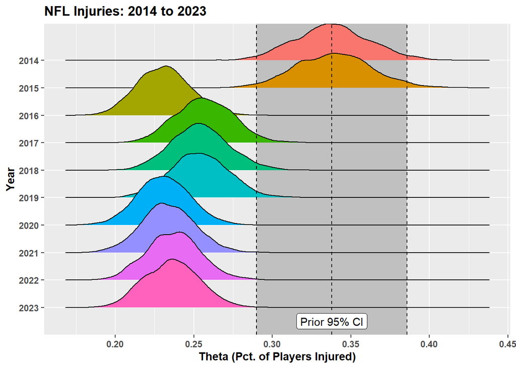

```r
print(p2)
```

we were able to distinguish that some factors within the NFL have led to a decreased injury rate in the last ten years. Whether it had to do with

- Theorized rule changes
- Shift in officiating flexibility
- Possible Other Factors

we were unsure.

When compared to the proportion of different age groups in the NFL over the years, we noticed a slight deviation around some periods of regression of younger players entering the league:

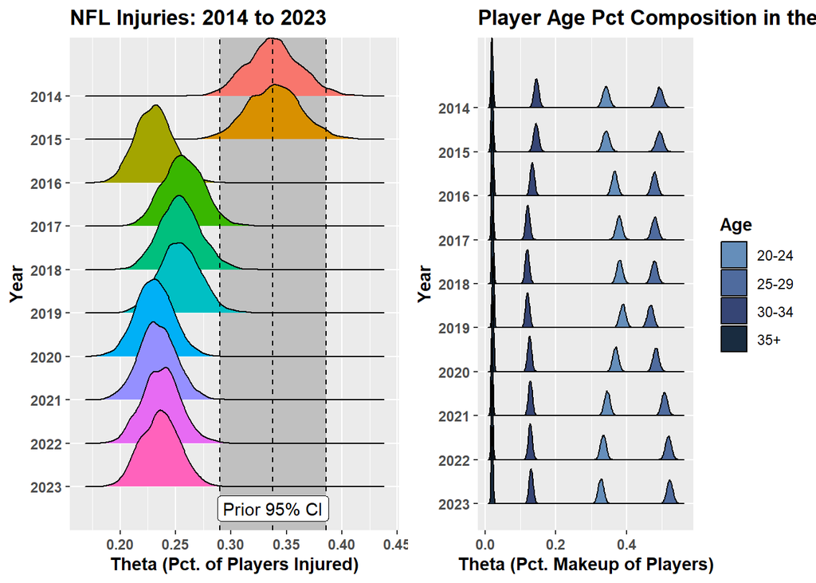

```r
plot_grid(p2, p5)
```

With this shifting of different aged players, we decided to look into the ratio of players that became injured compared to others in their age range.

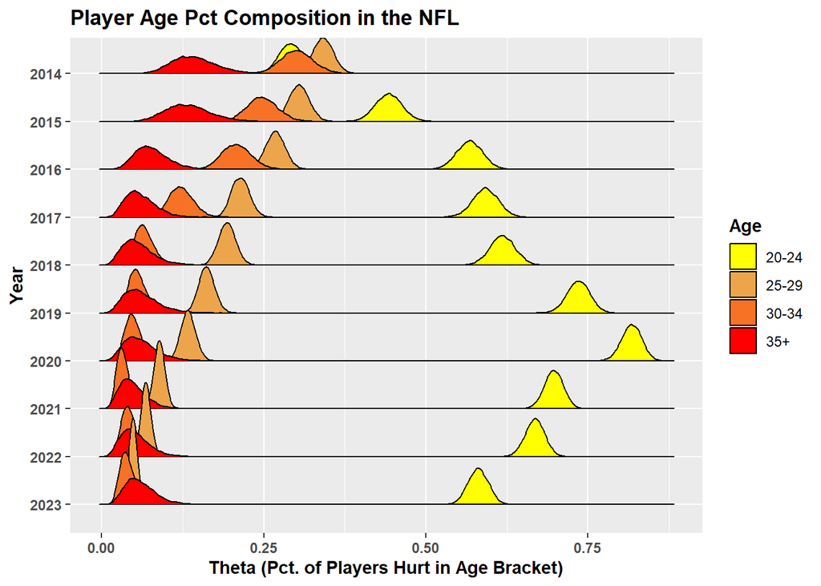

```r
print(p6)
```

And what we noticed is that there was a massive divergence in injuries from those under the age of 25 compared to all other athletes.

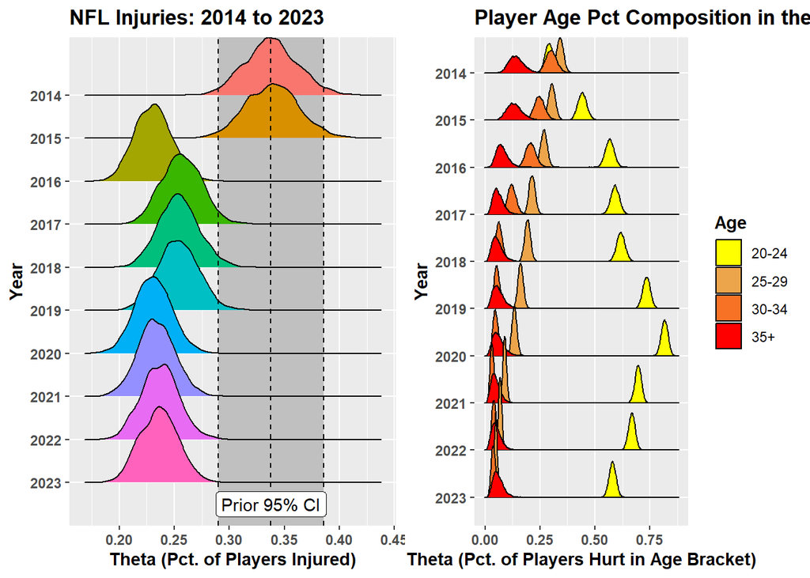

```r
plot_grid(p2, p6)
```

When we compare these findings with the percentage of players getting injured through the entire league however, just because younger players have been getting hurt more doesn’t correlate to the league’s injury rate also spiking. Instead, the decreased rate of injury for those over 25 years of age has caused the distributions to remain relatively stable for the past (roughly) 7 seasons.

This finding takes away from the idea that the demographic of players is a main contributing factor for the entire league’s rate of injury. Instead, I believe the next question to be asked is how to prevent younger players from getting hurt as much. Some ideas mentioned earlier include

- Changing training regimens for athletes at a young age (avoiding over-development early)
- Reexamining human physiological literature for athletes
- Stabilizing load management rates to express athletes to increase strain if they are being under stimulated
- Getting young players more prepared for the physicality of the professional game

That being said, it’s clear that some change occurred in the 2016 season to have significantly decreased injury percentage among players. While it can’t be definitevly claimed that rule changes are responsible, we analyzed age as a factor instead and found it to be inconclusive for explaining much of the change in distribution of league injuries over time.

Instead, further analysis should be conducted on the usage of players under the age of 25 to examine if that is the reason why they are being hurt so frequently, or if there is a separate reason.

## Conclusion

As the league continues to develop, strong evidence has been provided that some factors, perhaps rule changes, have positively impacted the injury rate among NFL athletes. While exploring potential factors for this finding, it was discovered that there has been an alarmingly large spike of young athlete injuries around the league as the game progresses. Determining the cause of these detriments to all players, especially those being most afflicted is extremely important in further research and analyses to help maintain player health and wellness. Future areas of exploration should evaluate player usage rates based on age help better distinguish what is impacting the NFL’s injury rate. These studies can help to keep players safer so that they can live happier, healthier lives and us fanatics can continue to watch our favorite teams and players on Sunday (or Monday… or Thursday).